```python
import geopandas as gp
import numpy as np
import os
import pandas as pd
import matplotlib as mtplt
import seaborn as sb
import matplotlib.pyplot as plt
from matplotlib.dates import DateFormatter
from matplotlib.ticker import FuncFormatter
import matplotlib.dates as mdates
```

# 1. [10 puntos] Con base en su experiencia indique posibles aplicaciones de la visualización de datos en su entorno profesional así como que tipo de visualizaciones espera poder desarrollar al finalizar el curso.

# 2. [20 puntos] Utilizando los datos de la tabla `cafe.csv` realice lo siguiente:

```python
datos = pd.read_csv("../datos/cafe.csv", index_col = 0)
datos.head()
```

|  | country_of_origin | aroma | flavor | aftertaste | acidity | body | balance | uniformity | total_cup_points |
| --- | --- | --- | --- | --- | --- | --- | --- | --- | --- |
| 1 | Ethiopia | 8.67 | 8.83 | 8.67 | 8.75 | 8.50 | 8.42 | 10.0 | 90.58 |
| 2 | Ethiopia | 8.75 | 8.67 | 8.50 | 8.58 | 8.42 | 8.42 | 10.0 | 89.92 |
| 3 | Guatemala | 8.42 | 8.50 | 8.42 | 8.42 | 8.33 | 8.42 | 10.0 | 89.75 |
| 4 | Ethiopia | 8.17 | 8.58 | 8.42 | 8.42 | 8.50 | 8.25 | 10.0 | 89.00 |
| 5 | Ethiopia | 8.25 | 8.50 | 8.25 | 8.50 | 8.42 | 8.33 | 10.0 | 88.83 |

## a) Lea el archivo y verifique que este se leyó correctamente utilizando la función `dtypes` de objeto pandas.

```python
datos.dtypes
```

```
country_of_origin     object
aroma                float64
flavor               float64
aftertaste           float64
acidity              float64
body                 float64
balance              float64
uniformity           float64
total_cup_points     float64
dtype: object
```

## b) Diseñe un prototipo del gráfico que permita comparar el comportamiento de la variable `total_cup_points` entre los diferentes países, este puede ser en papel o con ayuda de algún editor gráfico.

## c) Replique el gráfico diseñado en el punto anterior utilizando la biblioteca `matplotlib`.

```python
class MyPlot(plt.Axes):
    def __init__(self, *args, **kwargs):
      super().__init__(*args, **kwargs)

    def labs(self, title = "", x = "", y = "", title_pad = 10, title_size = 12):
      self.set_title(title, pad = title_pad, fontdict = {'fontsize':title_size})
      self.set_xlabel(x)
      self.set_ylabel(y)

    def theme_minimal(self):
      self.spines['top'].set_visible(False)
      self.spines['right'].set_visible(False)
      self.grid(color='grey', linestyle='-', linewidth=0.25, alpha=0.5)

    def add_points(self, data, x, y, color = None):
      if color is None:
        self.plot(data[x], data[y], 'o', ms = 3)
      else:
        for g in data[color].unique():
          d = data[data[color] == g]
          self.plot(d[x], d[y], 'o', ms = 3, label = g)
          legend = self.legend(handletextpad=0.05)
          lhs = legend.legendHandles
          for lh in lhs:
            lh._legmarker.set_markersize(4)

    def add_bars(self, data, x, y, label = False, fun = "mean", color = "#78c4d4"):
      d = data.groupby(x).agg(fun)
      bars = self.bar(d.index, d[y], color = color, alpha = 1)
      if label :
        for bar in bars:
          height = round(bar.get_height(),2)
          self.annotate('{}'.format(height),
                    xy=(bar.get_x() + bar.get_width() / 2, height),
                    xytext=(0, 3),
                    textcoords = "offset points",
                    ha = 'center', va = 'bottom')
```

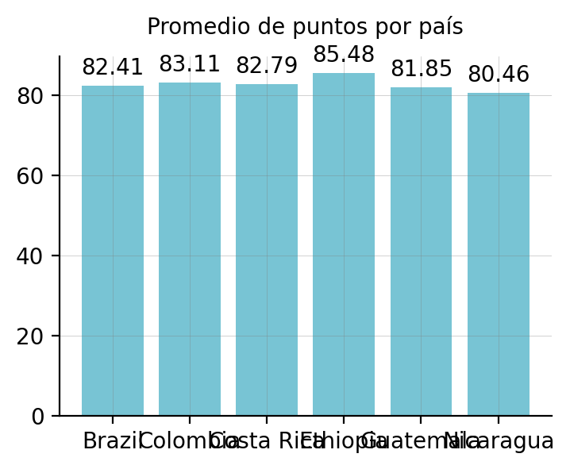

```python
fig, axes = plt.subplots(figsize=(4, 3), dpi = 200)
axes.__class__ = MyPlot

axes.labs(title = "Promedio de puntos por país",
          title_size = 10)
axes.theme_minimal()
axes.add_bars(data = datos , x = "country_of_origin" ,y = "total_cup_points", label= True)
```

## d) Repita el punto anterior esta vez utilizando la biblioteca `seanborn`.

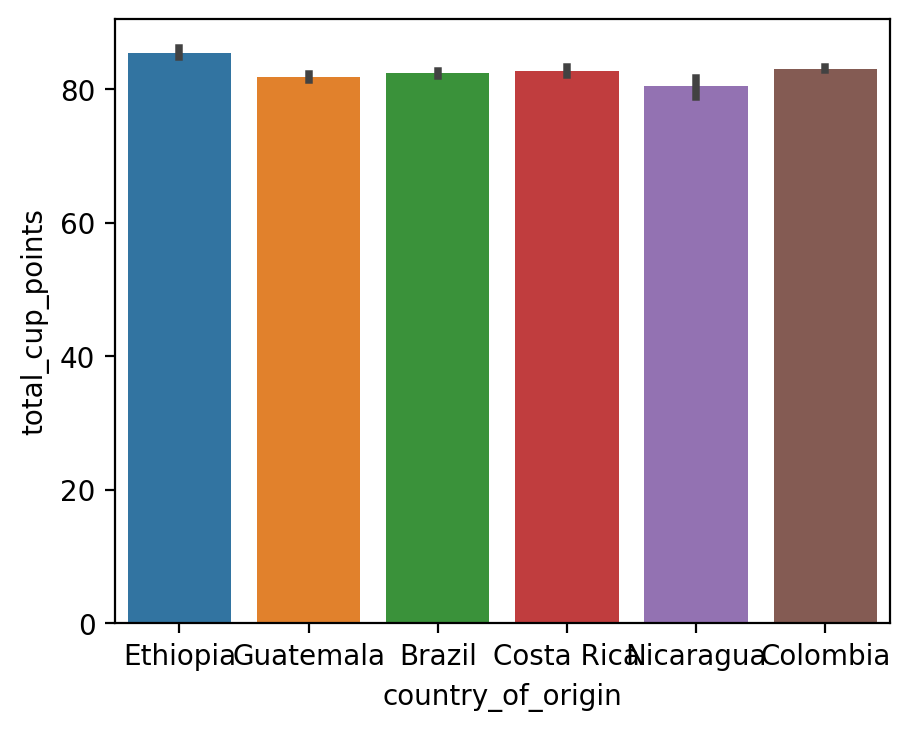

```python
fig, ax = plt.subplots(figsize=(5, 4), dpi = 200)
sb.barplot(x = "country_of_origin" ,y = "total_cup_points", data=datos, ax = ax)
```

# 4. [50 puntos] Utilizando la tabla `covid_nov28.csv` realice los siguiente:

## a) Lea el archivo y verifique que este se leyó correctamente utilizando la función `dtypes` de objeto pandas.

```python
datos = pd.read_csv("../datos/covid_28_nov.csv")
datos.fecha = pd.to_datetime(datos.fecha)
datos
```

|  | provincia | canton | fecha | activos |
| --- | --- | --- | --- | --- |
| 0 | San José | Acosta | 2020-04-21 | 0 |
| 1 | San José | Acosta | 2020-04-22 | 0 |
| 2 | San José | Acosta | 2020-04-23 | 0 |
| 3 | San José | Acosta | 2020-04-24 | 0 |
| 4 | San José | Acosta | 2020-04-25 | 0 |
| ... | ... | ... | ... | ... |
| 47388 | Otros | Otros | 2021-08-11 | 6 |
| 47389 | Otros | Otros | 2021-09-11 | 7 |
| 47390 | Otros | Otros | 2021-10-11 | 7 |
| 47391 | Otros | Otros | 2021-11-11 | 7 |
| 47392 | Otros | Otros | 2021-12-11 | 8 |

47393 rows × 4 columns

## c) Replique el gráfico del punto anterior utilizando la biblioteca `seanborn`.

[figure not shown]

```python
fig, ax = plt.subplots(figsize=(15, 5), dpi = 200)
sb.barplot(x = "canton" ,y = "activos", data=datos, ax = ax)
ax.tick_params(axis='x', rotation=90)
```

## e) Replique el gráfico del punto anterior utilizando la biblioteca `seanborn`.

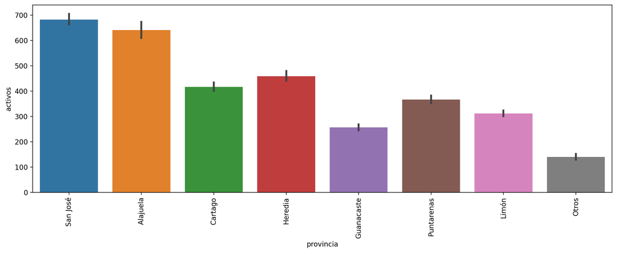

```python
fig, ax = plt.subplots(figsize=(15, 5), dpi = 200)
sb.barplot(x = "provincia" ,y = "activos", data=datos, ax = ax)
ax.tick_params(axis='x', rotation=90)
```

## f ) Diseñe utilizando lápiz y papel un gráfico que permita comparar la cantidad de casos activos a lo largo del año 2020, por provincia.

## g) Replique el gráfico del punto anterior utilizando la biblioteca `seanborn`.

```python
datos1 = datos.groupby(['fecha','provincia']).sum('activos')
```

[output not shown]

4568 rows × 1 columns

[figure not shown]

```python
import seaborn as sb

fig, ax = plt.subplots(figsize=(15,6),dpi=300)

sb.lineplot(data=datos1, x="fecha", y="activos", hue="provincia")

ax.set_title("Casos activos a lo largo del 2020")
ax.set_xlabel("")
```